# Cognitive Bias Modification for social anxiety: a living systematic review and network meta-analysis

#### 2.3.6.3 Inconsistency assessment

There were in total 10 different treatment comparisons included in loops in the network, and there is inconsistency (according to SIDE p-value<0.10) in 0, equal to 0%.

The p-value from the design-by-treatment test to evaluate global inconsistency is 0.44.

#### 2.3.6.4 Risk of bias

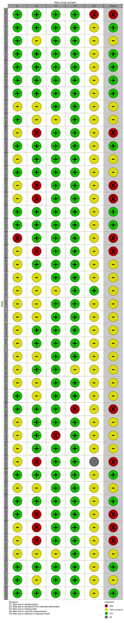

**Figure 32.** Risk of bias assessment for each study contributing data on acceptability using the RoB2 tool

### 2.3.7 Tolerability

Two of the included studies (Ferrari et al., 2018; Li et al., 2024) in the clinical source of evidence reported the number of participants who dropped out due to adverse event. Both studies reported that no participants dropped out due to adverse events.

### 2.3.8 Adverse events

Only one study reported adverse events as a result of CBM (Ferrari et al., 2018). The authors reported that in two of the CBM conditions (avoid negative training and approach positive training) participants experienced an increase in state anxiety immediately after the training phase.

## 2.4 Non-clinical population

### 2.4.1 Social anxiety

#### 2.4.1.1 Pairwise meta-analysis

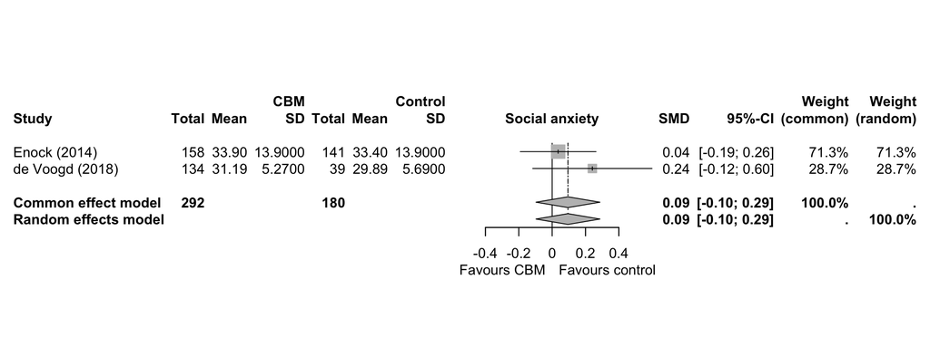

**Figure 33.** Forest plot for social anxiety comparing CBM vs control for individuals without social anxiety post intervention in the non-clinical population. SMD: standardised mean difference, 95% CI: 95% confidence intervals, SD: standard deviation.

The effect of CBM versus control in the non-clinical source showed a SMD of 0.09 (95% CI -0.1 to 0.29).

#### 2.4.1.2 Network meta-analysis

As only two studies from the non-clinical source contributed data on symptoms of social anxiety, network meta-analysis was not conducted.

#### 2.4.1.3 Risk of Bias

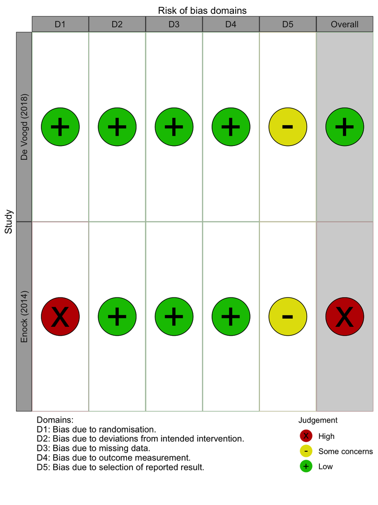

**Figure 33.** Risk of bias assessment for each study contributing data on social anxiety in the non-clinical population using the RoB2 tool

1 study (50%) were assessed as having ‘high’ risk of bias due to having ‘high’ risk of bias in at least one domain. 1 study (50%) had an overall ‘low’ risk of bias rating.

### 2.4.2 Depression

#### 2.4.2.1 Pairwise meta-analysis

As only one study from the non-clinical source contributed data on symptoms of depression in individuals without social anxiety, pairwise meta-analysis was not conducted.

#### 2.4.2.2 Network meta-analysis

As only 2 studies (de Voogt 2018, Vassilopoulos 2014) with a total of 4 disconnected treatments contributed data, network meta-analysis was not conducted.

### 2.4.3 General anxiety

#### 2.4.3.1 Pairwise meta-analysis

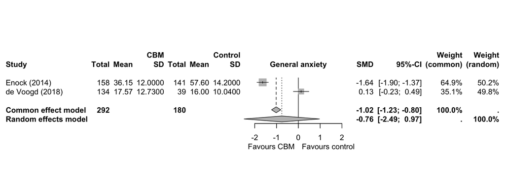

**Figure 34.** Forest plot for general anxiety comparing CBM vs control for individuals without social anxiety post intervention in the non-clinical population. SMD: standardised mean difference, 95% CI: 95% confidence intervals, SD: standard deviation.

The effect of CBM versus control in the non-clinical source showed a SMD of -0.76 (95% CI: -2.49 to 0.97).

#### 2.4.3.2 Network meta-analysis

As only two studies contributed data to the analysis, network meta-analysis was not conducted.

#### 2.4.3.3 Risk of bias

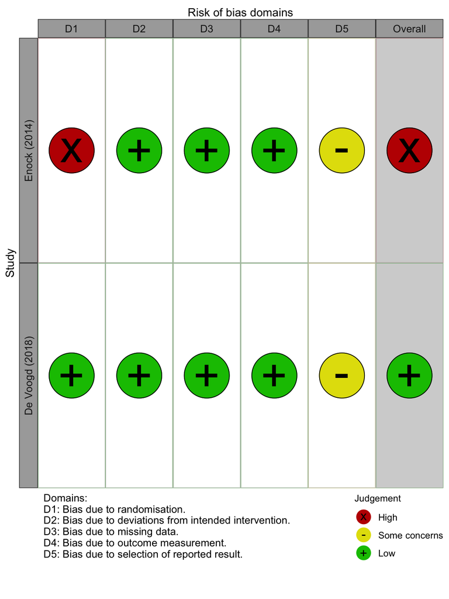

**Figure 35.** Risk of bias assessment for each study contributing data on general anxiety in the non-clinical population using the RoB2 tool

1 study (50%) were assessed as having ‘high’ risk of bias due to having ‘high’ risk of bias in at least one domain. 1 study (50%) had an overall ‘low’ risk of bias rating.

### 2.4.4 Change in bias

#### 2.4.4.1 Pairwise meta-analysis

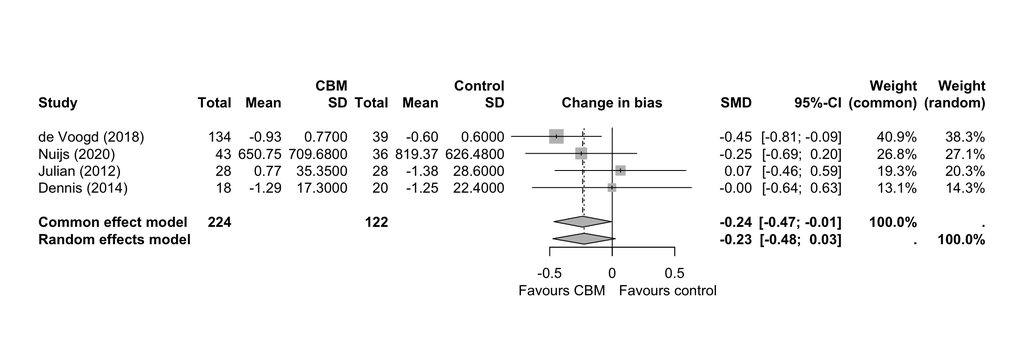

**Figure 36**. Forest plot for change in bias scores comparing CBM vs control for individuals without social anxiety post intervention in the non-clinical population. SMD: standardised mean difference, 95% CI: 95% confidence intervals, SD: standard deviation.

The effect of CBM versus control in the non-clinical source showed a SMD of -0.23 (95% CI -0.48 to 0.03).

#### 2.4.4.3 Risk of Bias

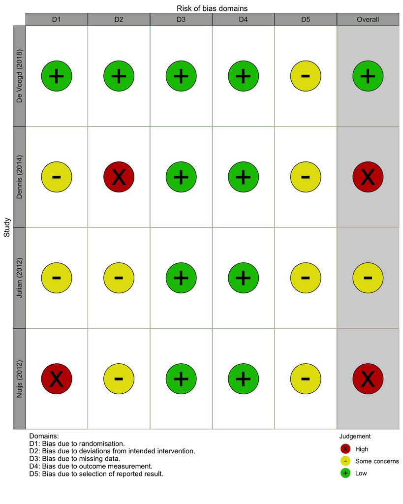

**Figure 37.** Risk of bias assessment for each study contributing data on change in bias in the non-clinical source of evidence using the RoB2 tool

### 2.4.5 Quality of life

#### 2.4.5.1 Pairwise meta-analysis

No studies in the non-clinical source reported data on quality of life and so pairwise meta-analysis was not conducted.

#### 2.4.5.2 Network meta-analysis

No studies in the non-clinical source reported data on quality of life and so network meta-analysis was not conducted.

### 2.4.6 Acceptability

#### 2.4.6.1 Pairwise meta-analysis

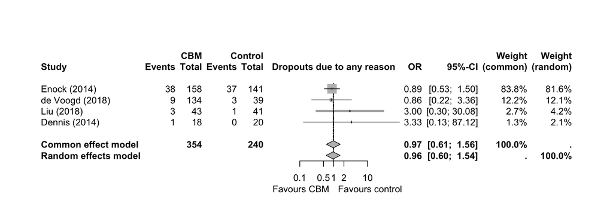

**Figure 38.** Forest plot for acceptability comparing CBM vs control for individuals without social anxiety post intervention in the non-clinical population. OR: odds ratio, 95% CI: 95% confidence intervals, SD: standard deviation.

The effect of CBM versus control in the non-clinical source showed an OR of 0.96 (95% CI: 0.6 to 1.54).

#### 2.4.6.2 Network meta-analysis

The data contributing to the analysis formed two disconnected subnetworks: one consisted of 3 studies, comparing CBM-A, control CBM-A, and waitlist; one consisted of 1 study comparing CBM-I and control CBM-I. As such, NMA was not conducted.

#### 2.4.6.3 Risk of Bias

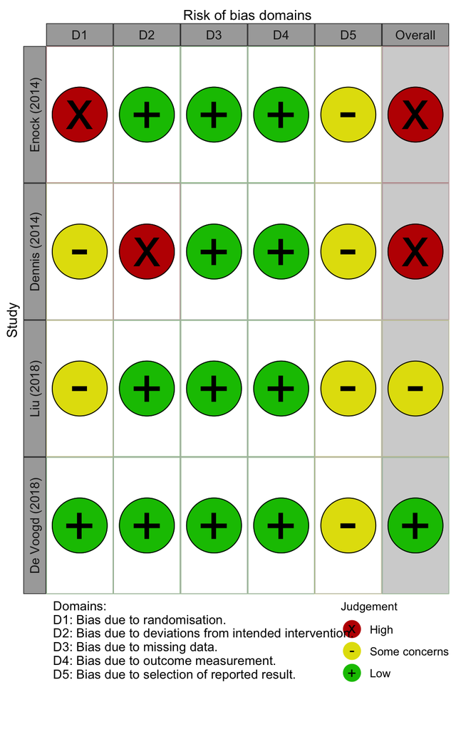

**Figure 39.** Risk of bias assessment for each study contributing data on acceptability in the non-clinical source of evidence using the RoB2 tool

### 2.4.7 Tolerability

No included in the non-clinical source of evidence reported dropouts due to adverse events.

### 2.4.8 Adverse events

No included studies in the non-clinical source of evidence reported adverse events.

# 3. Characteristics of included studies

| Study label | Country | Intervention | Participants (n) | Female participants | Mean age | Duration of treatment | Target of intervention | Mode of intervention | Stimuli used | Target bias | Number of sessions |
| --- | --- | --- | --- | --- | --- | --- | --- | --- | --- | --- | --- |
| Amir (2008) | USA | Control CBM-A | 53 | 25 | 19.0 | Single session | Attentional bias | Computer | Faces | Attentional | 1 |
| Amir (2008) | USA | CBM-A | 47 | 23 | 19.0 | Single session | Attentional bias | Computer | Faces | Attentional | 1 |
| Amir (2009) | USA | CBM-A | 22 | 14 | 27.6 | 4 weeks | Attentional bias | Computer | Faces | Attentional | 8 |
| Amir (2009) | USA | Control CBM-A | 26 | 14 | 31.1 | 4 weeks | Attentional bias | Computer | Faces | Attentional | 8 |
| Amir (2010) | USA | Control CBM-I | 28 | 17 | 20.0 | Single session | Interpretation bias | Computer | Sentences | Interpretation | 1 |
| Amir (2010) | USA | CBM-I | 29 | 13 | 19.0 | Single session | Interpretation bias | Computer | Sentences | Interpretation | 1 |
| Amir (2012) | USA | Control CBM-I | 26 | 16 | 33.1 | 6 weeks | Interpretation bias | Computer | Sentences | Interpretation | 12 |
| Amir (2012) | USA | CBM-I | 23 | 19 | 28.9 | 6 weeks | Interpretation bias | Computer | Sentences | Interpretation | 12 |
| Asnaani (2014) | USA | AAT | 21 | NR | NR | 1 week | Attentional bias | internet | Faces | Attentional | 3 |
| Asnaani (2014) | USA | Control AAT | 22 | NR | NR | 1 week | Attentional bias | internet | Faces | Attentional | 3 |
| Azriel (2024) | Israel | Control CBM-I | 25 | 14 | 30.3 | 4 weeks | Attentional bias | Computer | Faces; shapes; music | Attentional | 8 |
| Azriel (2024) | Israel | CBM-I | 25 | 9 | 30.0 | 4 weeks | Attentional bias | Computer | Faces; shapes; music | Attentional | 8 |
| Baert (2012) | Belgium | CBM-A | 14 | 6 | 26.4 | 6 days | Attentional bias | Computer | Faces | Attentional | 6 |
| Baert (2012) | Belgium | Control CBM-A | 14 | 11 | 26.6 | 6 days | Attentional bias | Computer | Faces | Attentional | 6 |
| Beard (2008) | USA | Control CBM-I | 14 | 13 | 20.0 | 4 weeks | Attentional bias | Computer; internet | Sentences | Interpretation | 6 |
| Beard (2008) | USA | CBM-I | 13 | 12 | 19.0 | 4 weeks | Attentional bias | Computer; internet | Sentences | Interpretation | 6 |
| Boettcher (2012) | Switzerland; Germany | CBM-A | 33 | 12 | 37.5 | 4 weeks | Approach bias | Computer | Faces | approach_bias | 8 |
| Boettcher (2012) | Switzerland; Germany | Control CBM-A | 35 | 13 | 38.3 | 4 weeks | Approach bias | Computer | Faces | approach_bias | 8 |
| Boettcher (2013) | Sweden | CBM-A | 43 | 26 | NA | 2 weeks | Attentional bias | Computer; internet | Faces, words | Attentional | 14 |
| Boettcher (2013) | Sweden | Control CBM-A | 43 | 23 | NA | 2 weeks | Attentional bias | Computer; internet | Faces, words | Attentional | 14 |
| Boettcher (2013) | Sweden | Opposite CBM-A | 43 | 33 | NA | 2 weeks | Attentional bias | Computer; internet | Faces, words | Attentional | 14 |
| Bomyea (2023) | USA | AAT | 21 | 16 | 22.7 | 2 weeks | Attentional bias | Computer | Faces | Attentional | 4 |
| Bomyea (2023) | USA | Control AAT | 24 | 14 | 23.4 | 2 weeks | Attentional bias | Computer | Faces | Attentional | 4 |
| Bowler (2012) | UK | CBM-I | 25 | 16 | 24.1 | 2 weeks | Interpretation bias | Computer | Sentences | Interpretation | 4 |
| Bowler (2012) | UK | Waitlist | 22 | 13 | 22.0 | 2 weeks | Interpretation bias | Computer | Sentences | Interpretation | 4 |
| Britton (2015) | USA | CBM-A | 26 | 12 | 21.8 | 4 weeks | Attentional bias | Computer | Words | Attentional | 9 |
| Britton (2015) | USA | Control CBM-A | 27 | 8 | 22.1 | 4 weeks | Attentional bias | Computer | Words | Attentional | 9 |
| Carey (2020) | UK | CBM-A | 12 | NR | 32.8 | Single session | Attentional bias | Computer | Words | Attentional | 1 |
| Carey (2020) | UK | Control CBM-A | 11 | NR | 30.7 | Single session | Attentional bias | Computer | Words | Attentional | 1 |
| Carlbring (2012) | Sweden | CBM-A | 40 | 14 | 35.1 | 4 weeks | Attentional bias | Computer; internet | Faces | Attentional | 8 |

[output cut: 165 more lines]

**Table 7.** Characteristics of included studies

# 4. ROB-MEN tables

| Pairwise comparison | Number of studies in each comparison | . | Within study assessment of bias | Across-study assessment of bias | Overall judgement |
| --- | --- | --- | --- | --- | --- |
| Group A: observed for this outcome | Reporing this outome (sample size) | Total identified in the systematic review (sample size) | . | . | . |
| CBM-A:CBM-I | 1 (41) | 3 (139) | No bias suspected | No bias suspected | No bias suspected |
| CBM-A:Combined control | 1 (40) | 3 (142) | No bias suspected | No bias suspected | No bias suspected |
| CBM-A:Control CBM-A | 19 (1092) | 28 (1680) | Suspected bias favouring CBM-A | Suspected bias favouring CBM-A | Suspected bias favouring CBM-A |
| CBM-A:Multicomponent | 1 (41) | 3 (133) | No bias suspected | No bias suspected | No bias suspected |
| CBM-A:Opposite CBM-A | 4 (272) | 6 (380) | Suspected bias favouring CBM-A | Suspected bias favouring CBM-A | Suspected bias favouring CBM-A |
| CBM-A:Waitlist | 1 (43) | 1 (43) | No bias suspected | No bias suspected | No bias suspected |
| CBM-I:Combined control | 1 (41) | 3 (141) | No bias suspected | No bias suspected | No bias suspected |
| CBM-I:Control CBM-I | 7 (354) | 11 (608) | Suspected bias favouring CBM-I | Suspected bias favouring CBM-I | Suspected bias favouring CBM-I |
| CBM-I:Multicomponent | 1 (42) | 3 (132) | No bias suspected | No bias suspected | No bias suspected |
| CBM-I:Opposite CBM-I | 1 (42) | 1 (42) | No bias suspected | Suspected bias favouring CBM-I | Suspected bias favouring CBM-I |
| CBM-I:TAU | 2 (149) | 2 (149) | No bias suspected | No bias suspected | No bias suspected |
| CBM-I:Waitlist | 5 (219) | 5 (219) | No bias suspected | No bias suspected | No bias suspected |
| Combined control:Multicomponent | 1 (41) | 3 (135) | No bias suspected | No bias suspected | No bias suspected |
| Control CBM-A:Multicomponent | 1 (65) | 1 (65) | No bias suspected | No bias suspected | No bias suspected |
| Control CBM-A:Opposite CBM-A | 3 (177) | 5 (269) | Suspected bias favouring opposite CBM-A | No bias suspected | Suspected bias favouring opposite CBM-A |
| Control CBM-A:Waitlist | 1 (43) | 1 (43) | No bias suspected | No bias suspected | No bias suspected |
| Group B: Observed for other outcomes | . | . | . | . | . |
| Multicomponent:Waitlist | NA | 1 (170) | No bias suspected | No bias suspected | No bias suspected |
| Group C: Unobserved | . | . | . | . | . |
| CBM-A:Control CBM-I | 0 | 0 | NA | No bias suspected | No bias suspected |
| CBM-A:Opposite CBM-I | 0 | 0 | NA | No bias suspected | No bias suspected |
| CBM-A:TAU | 0 | 0 | NA | No bias suspected | No bias suspected |
| CBM-I:Control CBM-A | 0 | 0 | NA | No bias suspected | No bias suspected |
| CBM-I:Opposite CBM-A | 0 | 0 | NA | No bias suspected | No bias suspected |
| Combined control:Control CBM-A | 0 | 0 | NA | No bias suspected | No bias suspected |
| Combined control:Control CBM-I | 0 | 0 | NA | No bias suspected | No bias suspected |
| Combined control:Opposite CBM-A | 0 | 0 | NA | No bias suspected | No bias suspected |
| Combined control:Opposite CBM-I | 0 | 0 | NA | No bias suspected | No bias suspected |
| Combined control:TAU | 0 | 0 | NA | No bias suspected | No bias suspected |
| Combined control:Waitlist | 0 | 0 | NA | No bias suspected | No bias suspected |
| Control CBM-A:Control CBM-I | 0 | 0 | NA | No bias suspected | No bias suspected |
| Control CBM-A:Opposite CBM-I | 0 | 0 | NA | No bias suspected | No bias suspected |
| Control CBM-A:TAU | 0 | 0 | NA | No bias suspected | No bias suspected |
| Control CBM-I:Multicomponent | 0 | 0 | NA | No bias suspected | No bias suspected |
| Control CBM-I:Opposite CBM-A | 0 | 0 | NA | No bias suspected | No bias suspected |
| Control CBM-I:Opposite CBM-I | 0 | 0 | NA | No bias suspected | No bias suspected |
| Control CBM-I:TAU | 0 | 0 | NA | No bias suspected | No bias suspected |
| Control CBM-I:Waitlist | 0 | 0 | NA | No bias suspected | No bias suspected |
| Multicomponent:Opposite CBM-A | 0 | 0 | NA | No bias suspected | No bias suspected |
| Multicomponent:Opposite CBM-I | 0 | 0 | NA | No bias suspected | No bias suspected |
| Multicomponent:TAU | 0 | 0 | NA | No bias suspected | No bias suspected |
| Opposite CBM-A:Opposite CBM-I | 0 | 0 | NA | No bias suspected | No bias suspected |
| Opposite CBM-A:TAU | 0 | 0 | NA | No bias suspected | No bias suspected |
| Opposite CBM-A:Waitlist | 0 | 0 | NA | No bias suspected | No bias suspected |
| Opposite CBM-I:TAU | 0 | 0 | NA | No bias suspected | No bias suspected |
| Opposite CBM-I:Waitlist | 0 | 0 | NA | No bias suspected | No bias suspected |
| TAU:Waitlist | 0 | 0 | NA | No bias suspected | No bias suspected |

**Table 8.** Pairwise comparison table for the ROB-MEN tool for the network of CBM for social anxiety. CBM-I = Cognitive Bias Modification for Interpretations; CBM-A = Cognitive Bias Modification for Attention; TAU = Treatment As Usual; Opposite CBM-I = Opposite Cognitive Bias Modification for Interpretations; Opposite CBM-A = Opposite Cognitive Bias Modification for Attention; Multicomponent = Multicomponent CBM; Control CBM-I; Control CBM-I = Control Cognitive Bias Modification for Interpretations; Control CBM-A = Control Cognitive Bias Modification for Attention.

| Comparison | % contribution of evidence from pairwise comparisons with suspected bias | . | Evaluation of contribution from evidence with suspected bias | Bias assessment for indirect evidence | NMA treatment effect | NMR treatment effects at the smallest observed variance | Evaluation of small study effects | Overall risk of bias |
| --- | --- | --- | --- | --- | --- | --- | --- | --- |
| . | Favouring first treatment | Favouring second treatment | . | . | SMD (95%CI) | SMD (95%CI) | . | . |
| Mixed/only direct | . | . | . | . | . | . | . | . |
| CBM-A:CBM-I | 6.9 | 0 | No bias detected | . | 0.63 (-0.19,1.45) | 1.6 (0.72,2.64) | Small study effects favouring CBM-I | Some concerns |
| CBM-A:Combined control | 4.5 | 0 | No bias detected | . | 1.09 (0.04,2.17) | 2.06 (1.05,3.08) | No evidence of small study effects | Low risk |
| CBM-A:Control CBM-A | 89.7 | 0 | Substantial contibution from bias favouring CBM-A | . | 0.16 (-0.09,0.42) | 0.12 (-0.15,0.39) | No evidence of small study effects | Some concerns |
| CBM-A:Multicomponent | 10.8 | 0 | No bias detected | . | 1.05 (0.26,1.86) | 2.81 (1.79,3.8) | Small study effects favouring CBM-A | Some concerns |
| CBM-A:Opposite CBM-A | 78.4 | 19.5 | Substantial contibution from bias favouring CBM-A | . | 0 (-0.53,0.53) | -0.16 (-0.66,0.36) | No evidence of small study effects | Some concerns |
| CBM-A:Waitlist | 13 | 0 | No bias detected | . | 0.82 (0.02,1.61) | 1.49 (0.44,2.73) | No evidence of small study effects | Low risk |
| CBM-I:Combined control | 0 | 0 | No bias detected | . | 0.47 (-0.62,1.57) | 0.44 (-0.46,1.31) | No evidence of small study effects | Low risk |
| CBM-I:Control CBM-I | 100 | 0 | Substantial contibution from bias favouring CBM-I | . | 0.43 (-0.02,0.87) | 0.27 (-0.2,0.76) | No evidence of small study effects | Some concerns |
| CBM-I:Multicomponent | 0 | 0 | No bias detected | . | 0.43 (-0.53,1.37) | 1.19 (0.29,2.02) | No evidence of small study effects | Low risk |
| CBM-I:Opposite CBM-I | 100 | 0 | Substantial contibution from bias favouring CBM-I | . | 0.69 (-0.49,1.88) | 0.7 (-0.99,2.61) | No evidence of small study effects | Some concerns |
| CBM-I:TAU | 0 | 0 | No bias detected | . | 0.51 (-0.29,1.3) | 0.8 (-0.05,1.81) | No evidence of small study effects | Low risk |
| CBM-I:Waitlist | 0 | 0 | No bias detected | . | 0.19 (-0.31,0.69) | -0.11 (-0.74,0.54) | No evidence of small study effects | Low risk |
| Combined control:Multicomponent | 0 | 0 | No bias detected | . | -0.04 (-1.15,1.02) | 0.74 (-0.15,1.63) | No evidence of small study effects | Low risk |
| Control CBM-A:Multicomponent | 0 | 0 | No bias detected | . | 0.89 (0.11,1.69) | 2.7 (1.64,3.7) | Small study effects favouring control CBM-A | Some concerns |
| Control CBM-A:Opposite CBM-A | 0 | 47 | Substantial contibution from bias favouring opposite CBM-A | . | -0.16 (-0.7,0.37) | -0.27 (-0.79,0.25) | No evidence of small study effects | Some concerns |
| Control CBM-A:Waitlist | 0 | 0 | No bias detected | . | 0.66 (-0.15,1.46) | 1.37 (0.32,2.61) | No evidence of small study effects | Low risk |
| Indirect | . | . | . | . | . | . | . | . |
| Multicomponent:Waitlist | 0 | 0 | No bias detected | No bias detected | -0.24 (-1.22,0.75) | -1.29 (-2.35,-0.19) | Small study effects favouring waitlist | Low risk |
| CBM-A:Control CBM-I | 5.2 | 0 | No bias detected | No bias detected | 1.05 (0.14,1.99) | 1.88 (0.88,3.01) | No evidence of small study effects | Low risk |
| CBM-A:Opposite CBM-I | 5.2 | 0 | No bias detected | No bias detected | 1.32 (-0.12,2.76) | 2.28 (0.61,4.55) | No evidence of small study effects | Low risk |
| CBM-A:TAU | 5.2 | 0 | No bias detected | No bias detected | 1.13 (0,2.29) | 2.4 (1.12,3.98) | Small study effects favouring CBM-A | Low risk |
| CBM-I:Control CBM-A | 0 | 0 | No bias detected | No bias detected | -0.46 (-1.28,0.36) | -1.48 (-2.54,-0.57) | Small study effects favouring control CBM-A | Low risk |
| CBM-I:Opposite CBM-A | 0 | 12.4 | No bias detected | No bias detected | -0.63 (-1.58,0.33) | -1.76 (-2.87,-0.73) | Small study effects favouring opposite CBM-A | Low risk |
| Combined control:Control CBM-A | 0 | 0 | No bias detected | No bias detected | -0.93 (-2.02,0.12) | -1.95 (-2.98,-0.9) | No evidence of small study effects | Low risk |
| Combined control:Control CBM-I | 0 | 0 | No bias detected | No bias detected | -0.04 (-1.24,1.14) | -0.17 (-1.15,0.87) | No evidence of small study effects | Low risk |
| Combined control:Opposite CBM-A | 0 | 10.8 | No bias detected | No bias detected | -1.09 (-2.28,0.08) | -2.22 (-3.34,-1.07) | No evidence of small study effects | Low risk |
| Combined control:Opposite CBM-I | 0 | 0 | No bias detected | No bias detected | 0.23 (-1.43,1.84) | 0.26 (-1.51,2.31) | No evidence of small study effects | Low risk |
| Combined control:TAU | 0 | 0 | No bias detected | No bias detected | 0.03 (-1.32,1.4) | 0.36 (-0.83,1.74) | No evidence of small study effects | Low risk |
| Combined control:Waitlist | 0 | 0 | No bias detected | No bias detected | -0.28 (-1.43,0.84) | -0.55 (-1.62,0.55) | No evidence of small study effects | Low risk |
| Control CBM-A:Control CBM-I | 0 | 0 | No bias detected | No bias detected | 0.89 (-0.02,1.83) | 1.76 (0.74,2.94) | No evidence of small study effects | Low risk |
| Control CBM-A:Opposite CBM-I | 0 | 0 | No bias detected | No bias detected | 1.16 (-0.27,2.61) | 2.16 (0.48,4.47) | No evidence of small study effects | Low risk |
| Control CBM-A:TAU | 0 | 0 | No bias detected | No bias detected | 0.97 (-0.17,2.1) | 2.28 (0.98,3.9) | Small study effects favouring control CBM-A | Low risk |
| Control CBM-I:Multicomponent | 0 | 0 | No bias detected | No bias detected | 0 (-1.07,1.05) | 0.91 (-0.1,1.88) | No evidence of small study effects | Low risk |
| Control CBM-I:Opposite CBM-A | 0 | 9.5 | No bias detected | No bias detected | -1.06 (-2.12,0.01) | -2.04 (-3.22,-0.89) | No evidence of small study effects | Low risk |
| Control CBM-I:Opposite CBM-I | 0 | 0 | No bias detected | No bias detected | 0.27 (-1.01,1.55) | 0.43 (-1.34,2.41) | No evidence of small study effects | Low risk |
| Control CBM-I:TAU | 0 | 0 | No bias detected | No bias detected | 0.08 (-0.83,0.98) | 0.53 (-0.47,1.65) | No evidence of small study effects | Low risk |
| Control CBM-I:Waitlist | 0 | 0 | No bias detected | No bias detected | -0.24 (-0.91,0.43) | -0.38 (-1.19,0.43) | No evidence of small study effects | Low risk |
| Multicomponent:Opposite CBM-A | 0 | 15.3 | Substantial contibution from bias favouring opposite CBM-A | No bias detected | -1.05 (-2,-0.13) | -2.97 (-4.04,-1.8) | Small study effects favouring opposite CBM-A | High risk |
| Multicomponent:Opposite CBM-I | 0 | 0 | No bias detected | No bias detected | 0.28 (-1.25,1.77) | -0.47 (-2.29,1.56) | No evidence of small study effects | Low risk |
| Multicomponent:TAU | 0 | 0 | No bias detected | No bias detected | 0.08 (-1.16,1.33) | -0.37 (-1.51,0.93) | No evidence of small study effects | Low risk |
| Opposite CBM-A:Opposite CBM-I | 9.5 | 0 | No bias detected | No bias detected | 1.33 (-0.2,2.84) | 2.44 (0.69,4.71) | No evidence of small study effects | Low risk |
| Opposite CBM-A:TAU | 9.5 | 0 | No bias detected | No bias detected | 1.13 (-0.1,2.38) | 2.57 (1.15,4.19) | Small study effects favouring opposite CBM-A | Low risk |
| Opposite CBM-A:Waitlist | 16.4 | 0 | Substantial contibution from bias favouring opposite CBM-A | No bias detected | 0.82 (-0.13,1.78) | 1.64 (0.52,2.94) | No evidence of small study effects | Some concerns |
| Opposite CBM-I:TAU | 0 | 0 | No bias detected | No bias detected | -0.19 (-1.63,1.26) | 0.07 (-1.68,2.08) | No evidence of small study effects | Low risk |
| Opposite CBM-I:Waitlist | 0 | 0 | No bias detected | No bias detected | -0.51 (-1.79,0.8) | -0.83 (-2.81,1.05) | No evidence of small study effects | Low risk |
| TAU:Waitlist | 0 | 0 | No bias detected | No bias detected | -0.32 (-1.26,0.62) | -0.92 (-2.04,0.16) | No evidence of small study effects | Low risk |

**Table 9.** ROB-MEN table for the CBM for social anxiety network. NMA = network meta-analysis, NMR = network meta-regression, CBM-I = Cognitive Bias Modification for Interpretations; CBM-A = Cognitive Bias Modification for Attention; TAU = Treatment As Usual; Opposite CBM-I = Opposite Cognitive Bias Modification for Interpretations; Opposite CBM-A = Opposite Cognitive Bias Modification for Attention; Multicomponent = Multicomponent CBM; Control CBM-I; Control CBM-I = Control Cognitive Bias Modification for Interpretations; Control CBM-A = Control Cognitive Bias Modification for Attention; SMD = Standardised Mean Difference.

# 5. CINeMA Report

| Comparison | Number of studies | Within-study bias | Reporting bias | Indirectness | Imprecision | Heterogeneity | Incoherence | Confidence rating | Reason(s) for downgrading |
| --- | --- | --- | --- | --- | --- | --- | --- | --- | --- |
| CBM-A:CBM-I | 1 | Some concerns | Some concerns | No concerns | Some concerns | Some concerns | Major concerns | Low | Incoherence, |
| CBM-A:Combined control | 1 | Some concerns | Low risk | No concerns | Some concerns | Some concerns | Major concerns | Low | Incoherence, |
| CBM-A:Control CBM-A | 19 | Some concerns | Some concerns | No concerns | Some concerns | Some concerns | Some concerns | Moderate | Within-study bias, Reporting bias, Imprecision, Heterogeneity, Incoherence, |
| CBM-A:Multicomponent | 1 | Some concerns | Some concerns | No concerns | No concerns | Major concerns | Major concerns | Very low | Heterogeneity, Incoherence, |
| CBM-A:Opposite CBM-A | 4 | Some concerns | Some concerns | No concerns | Major concerns | No concerns | No concerns | Low | Imprecision, |
| CBM-A:Waitlist | 1 | Some concerns | Low risk | No concerns | No concerns | Major concerns | No concerns | Low | Heterogeneity, |
| CBM-I:Combined control | 1 | Some concerns | Low risk | No concerns | Major concerns | No concerns | No concerns | Low | Imprecision, |
| CBM-I:Control CBM-I | 7 | Some concerns | Some concerns | No concerns | No concerns | Major concerns | Major concerns | Very low | Within-study bias, Reporting bias, Heterogeneity, Incoherence, |
| CBM-I:Multicomponent | 1 | Some concerns | Low risk | No concerns | Major concerns | No concerns | Major concerns | Very low | Within-study bias, Imprecision, Incoherence, |
| CBM-I:Opposite CBM-I | 1 | Some concerns | Some concerns | No concerns | Major concerns | No concerns | Major concerns | Very low | Within-study bias, Reporting bias, Imprecision, Incoherence, |
| CBM-I:TAU | 2 | Major concerns | Low risk | No concerns | Some concerns | Some concerns | Major concerns | Very low | Within-study bias, Imprecision, Heterogeneity, Incoherence, |
| CBM-I:Waitlist | 5 | Some concerns | Low risk | No concerns | Major concerns | No concerns | No concerns | Low | Imprecision, |
| Combined control:Multicomponent | 1 | Some concerns | Low risk | No concerns | Major concerns | No concerns | Major concerns | Very low | Within-study bias, Imprecision, Incoherence, |
| Control CBM-A:Multicomponent | 1 | Some concerns | Some concerns | No concerns | Some concerns | Some concerns | Major concerns | Low | Incoherence, |
| Control CBM-A:Opposite CBM-A | 3 | Some concerns | Some concerns | No concerns | Major concerns | No concerns | No concerns | Moderate | Imprecision, |
| Control CBM-A:Waitlist | 1 | Some concerns | Low risk | No concerns | Some concerns | Some concerns | No concerns | Moderate | Within-study bias, Imprecision, Heterogeneity, |
| CBM-A:Control CBM-I | 0 | Some concerns | Low risk | No concerns | No concerns | Some concerns | Major concerns | Low | Incoherence, |
| CBM-A:Opposite CBM-I | 0 | Some concerns | Low risk | No concerns | No concerns | Major concerns | Major concerns | Very low | Within-study bias, Heterogeneity, Incoherence, |
| CBM-A:TAU | 0 | Some concerns | Low risk | No concerns | No concerns | Major concerns | Major concerns | Very low | Within-study bias, Heterogeneity, Incoherence, |
| CBM-I:Control CBM-A | 0 | Some concerns | Low risk | No concerns | Major concerns | No concerns | Major concerns | Very low | Within-study bias, Imprecision, Incoherence, |
| CBM-I:Opposite CBM-A | 0 | Some concerns | Low risk | No concerns | Some concerns | Some concerns | Major concerns | Low | Incoherence, |
| Combined control:Control CBM-A | 0 | Some concerns | Low risk | No concerns | Some concerns | Some concerns | Major concerns | Low | Incoherence, |
| Combined control:Control CBM-I | 0 | Some concerns | Low risk | No concerns | Major concerns | No concerns | Major concerns | Very low | Within-study bias, Imprecision, Incoherence, |
| Combined control:Opposite CBM-A | 0 | Some concerns | Low risk | No concerns | Some concerns | Some concerns | Major concerns | Low | Incoherence, |
| Combined control:Opposite CBM-I | 0 | Some concerns | Low risk | No concerns | Major concerns | No concerns | Major concerns | Very low | Within-study bias, Imprecision, Incoherence, |
| Combined control:TAU | 0 | Some concerns | Low risk | No concerns | Major concerns | No concerns | Major concerns | Very low | Within-study bias, Imprecision, Incoherence, |
| Combined control:Waitlist | 0 | Some concerns | Low risk | No concerns | Major concerns | No concerns | Major concerns | Very low | Within-study bias, Imprecision, Incoherence, |
| Control CBM-A:Control CBM-I | 0 | Some concerns | Low risk | No concerns | No concerns | Major concerns | Major concerns | Very low | Within-study bias, Heterogeneity, Incoherence, |
| Control CBM-A:Opposite CBM-I | 0 | Some concerns | Low risk | No concerns | Some concerns | Some concerns | Major concerns | Low | Incoherence, |
| Control CBM-A:TAU | 0 | Some concerns | Low risk | No concerns | Some concerns | Some concerns | Major concerns | Low | Incoherence, |
| Control CBM-I:Multicomponent | 0 | Some concerns | Low risk | No concerns | Major concerns | No concerns | Major concerns | Very low | Within-study bias, Imprecision, Incoherence, |
| Control CBM-I:Opposite CBM-A | 0 | Some concerns | Low risk | No concerns | No concerns | Major concerns | Major concerns | Very low | Within-study bias, Heterogeneity, Incoherence, |
| Control CBM-I:Opposite CBM-I | 0 | Some concerns | Low risk | No concerns | Major concerns | No concerns | Major concerns | Very low | Within-study bias, Imprecision, Incoherence, |
| Control CBM-I:TAU | 0 | Major concerns | Low risk | No concerns | Major concerns | No concerns | Major concerns | Very low | Imprecision, Incoherence, |
| Control CBM-I:Waitlist | 0 | Some concerns | Low risk | No concerns | Major concerns | No concerns | Major concerns | Very low | Within-study bias, Imprecision, Incoherence, |
| Multicomponent:Opposite CBM-A | 0 | Some concerns | High risk | No concerns | Some concerns | Some concerns | Major concerns | Very low | Within-study bias, Reporting bias, Imprecision, Heterogeneity, Incoherence, |
| Multicomponent:Opposite CBM-I | 0 | Some concerns | Low risk | No concerns | Major concerns | No concerns | Major concerns | Very low | Within-study bias, Imprecision, Incoherence, |
| Multicomponent:TAU | 0 | Some concerns | Low risk | No concerns | Major concerns | No concerns | Major concerns | Very low | Within-study bias, Imprecision, Incoherence, |
| Multicomponent:Waitlist | 0 | Some concerns | Low risk | No concerns | Major concerns | No concerns | Major concerns | Very low | Within-study bias, Imprecision, |
| Opposite CBM-A:Opposite CBM-I | 0 | Some concerns | Low risk | No concerns | Some concerns | Some concerns | Major concerns | Low | Incoherence, |
| Opposite CBM-A:TAU | 0 | Some concerns | Low risk | No concerns | No concerns | Major concerns | Major concerns | Very low | Within-study bias, Heterogeneity, Incoherence, |
| Opposite CBM-A:Waitlist | 0 | Some concerns | Some concerns | No concerns | Some concerns | Some concerns | Major concerns | Low | Incoherence, |
| Opposite CBM-I:TAU | 0 | Major concerns | Low risk | No concerns | Major concerns | No concerns | Major concerns | Very low | Within-study bias, Imprecision, Incoherence, |
| Opposite CBM-I:Waitlist | 0 | Some concerns | Low risk | No concerns | Major concerns | No concerns | Major concerns | Very low | Within-study bias, Imprecision, Incoherence, |
| TAU:Waitlist | 0 | Major concerns | Low risk | No concerns | Major concerns | No concerns | Major concerns | Very low | Within-study bias, Imprecision, Incoherence, |

**Table 10.** Assessments for each domain in the CINeMA assessment for the network estimate for CBM in social anxiety.The table shows levels fo concern for each of the 6 domains in CINeMA for each comparison. Range of equivalence = -0.24 to 0.24. SMD = Standardised Mean Difference; CBM-I = Cognitive Bias Modification for Interpretations; CBM-A = Cognitive Bias Modification for Attention; TAU = Treatment As Usual; Opposite CBM-I = Opposite Cognitive Bias Modification for Interpretations; Opposite CBM-A = Opposite Cognitive Bias Modification for Attention; Multicomponent = Multicomponent CBM; Control CBM-I; Control CBM-I = Control Cognitive Bias Modification for Interpretations; Control CBM-A = Control Cognitive Bias Modification for Attention.

# 6. Summary of Evidence table

The comparisons displayed in the summary of evidence protocol were chosen in consultation with topic experts in order to select ones with the most clinical relevance. The summary of evidence was completed at network level in order to better evaluate the evidence for these complex and heterogeneous interventions. This was a deviation from the protocol, which specified that the summary of evidence would be done at pairwise level. Future iterations of this LSR will also report the summary of evidence at network level. Due to the lack of available data, social anxiety is the only outcome shown in the summary of evidence table. Future iterations of the LSR will evaluate the summary of evidence for other outcomes and the non-clinical source, if data allows.

[output not shown]

**Table 11.** Summary of the direct and indirect evidence on the efficacy of CBM subtypes for individuals with social anxiety. CI = Confidence Interval; PI = Prediction Interval; SMD = standardised mean difference (network estimate) N = number of studies; n = number of participants. CBM-A = Cognitive Bias Modification for Attention; Control CBM-A = Control Cognitive Bias Modification for Attention; Opposite CBM-A = Opposite Cognitive Bias Modification for Attention; CBM-I = Cognitive Bias Modification for Interpretation; Control CBM-I = Control Cognitive Bias Modification for Interpretation; Opposite CBM-I = Opposite Cognitive Bias Modification for Interpretation.

# 7. Details of mediators

| Amir (2008) |
| --- |
| Page 6: Our results indicated that the 95% confidence intervals of the indirect path (alpha–beta) did not overlap with zero for change in state anxiety (lower limit .015, upper limit .203) and observe… |
| Amir (2009) |
| We computed an attention bias score by subtracting response latencies for invalid social threat trials from invalid neutral trials on the Attention Bias Assessment Task. Change in attention bias and c… |
| Amir (2012) |
| We used bootstrapping procedures (Preacher & Hayes, 2008) to test the indirect effect of treatment condition (Group: IMP, ICC) on reduction in clinician-rated social anxiety symptoms (LSAS) from pre- … |
| Page 12: change in interpretation bias, which suggested partial mediation, B = .73 (SE = .32), t(39) = 2.25, p = .03 (path c′). |
| Beard (2008) |
| Page 4: To test the hypothesis that the IMP exerted its inﬂuence on social anxiety through change in interpretation bias, we tested both threat interpretation and benign interpretation as potential me… |
| Page 5: We examined the number of participants in each group who correctly identiﬁed their condition assignment. For the IMP group, six participants correctly identiﬁed that they received the active c… |
| Bowler (2012) |
| Page 10: status (dummy coded as one for the control condition and zero for the active condition), and overall change across the symptom scales (FNE, BDI-II, STAI, and SPIN; z-transformed and then aver… |
| Page 9: We used the multiple mediation procedure developed by Preacher and Hayes (2008) to examine whether change in symptoms in the two active interventions was driven by change in interpretive bias … |
| Heeren (2011) |
| Page 6: To examine whether the effects of attentional training task on behavioral measures were mediated by changes in the ability to disengage attention from social threat, we performed mediational a… |
| Liu (2018) |
| Page 15: Mediation models were conducted on the fMRI cohort (ABM=15, placebo=19) to explore whether changes in neural activations from BLN to OCM mediate the ABM effect in reducing anxiety symptoms. T… |
| Page 16: Table S6. Results of Mediation Models Examining ΔfMRI as the Potential Mediator Between ABM Training and Δanxiety Effect SE t ΔRight amygdala p 95% CI a -0.82 0.50 -1.64 0.11 [-1.83, 0.20] b … |
| Mobini (2014) |
| Page 6: The mediation analysis was conducted to examine whether changes in either positive interpretations or attentional biases would independently mediate change in social anxiety. We entered group,… |
| Podina (2020) |
| Page 14: Mediation Analysis In the following, considering that anxiety decreased significantly in the CBM I group from baseline to post-training, we tested whether changes in adaptive interpretation b… |
| Salemink (2007) |
| Page 9: Secondly, to appraise the inﬂuence of this explicit knowledge on the actual interpretive bias shown following training, the analyses of the recognition ratings were repeated with level of know… |
| Yeung (2019) |
| Page 6: . If results supported a potential mediation, a Sobel Test was planned to determine whether the mediation was significant. |
| Page 8: No significant correlations between change in biases and outcome variables were observed. Therefore, the planned mediation analyses were abandoned. |

**Table 12** Extracted details on mediators in the included studies

# 8. Abbreviations

- AAT: Approach Avoidance Training
- CBM-A: Cognitive Bias Modification for Attention
- CBM-I: Cognitive Bias Modification for Interpretations
- CI: Confidence Interval
- CINeMA: Confidence in Network Meta-Analysis
- Control AAT: Control Approach Avoidance Training
- Control CBM-I: Control Cognitive Bias Modification for Interpretations
- Control CBM-A: Control Cognitive Bias Modification for Attention
- GALENOS: Global Alliance for Living Evidence on aNxiety depressiOn and pSychosis
- OR: Odds Ratio
- N: number of studies
- n: number of participants
- Opposite CBM-A: Opposite Cognitive Bias Modification for Attention
- Opposite CBM-I: Opposite Cognitive Bias Modification for Interpretation
- NMA: Network Meta-Analysis
- SD: Standard Deviation
- SIDE: Separate Indirect from Direct Evidence
- SMD: Standard Mean Difference
- SUCRA: Surface Under the Cumulative Ranking curve
- REML: Restricted Maximum Likelihood
- RoB2: Risk of Bias 2
- ROB-MEN: Risk of Bias for Missing Evidence in Network Meta Analysis
- TAU: Treatment As Usual

# 9. Software Used

We used R version 4.3.1 (R Core Team 2023) and the following packages; netmeta (Balduzzi et al., 2023) dplyr (Wickham et al. 2023); readxl (Wickham and Bryan, 2023); kableExtra (Zhu, 2024), robvis (McGuiness and Higgins, 2019).

# 10. List of included studies

Amir N & Taylor C T. (2012). Interpretation training in individuals with generalized social anxiety disorder: A randomized controlled trial. Journal of Consulting and Clinical Psychology, 80(3), 497–511. https://dx.doi.org/10.1037/a0026928 Amir Nader, Beard Courtney, Taylor Charles T, Klumpp Heide, Elias Jason, Burns Michelle, & Chen Xi. (2009). Attention training in individuals with generalized social phobia: A randomized controlled trial. Journal of Consulting and Clinical Psychology, 77(5), 961–973. https://dx.doi.org/10.1037/a0016685

Amir Nader, Bomyea Jessica, & Beard Courtney. (2010). The effect of single-session interpretation modification on attention bias in socially anxious individuals. Journal of Anxiety Disorders, 24(2), 178–182. https://dx.doi.org/10.1016/j.janxdis.2009.10.005

Amir Nader, Weber Geri, Beard Courtney, Bomyea Jessica, & Taylor Charles T. (2008). The effect of a single-session attention modification program on response to a public-speaking challenge in socially anxious individuals. Journal of Abnormal Psychology, 117(4), 860–868. https://dx.doi.org/10.1037/a0013445

Asnaani Anu, Rinck Mike, Becker Eni, & Hofmann Stefan G. (2014). The Effects of Approach-Avoidance Modification on Social Anxiety Disorder: A Pilot Study. Cognitive Therapy and Research, 38(2), 226–238. https://dx.doi.org/10.1007/s10608-013-9580-x

Azriel Omer, Arad Gal, Pine Daniel S, Lazarov Amit, & Bar-Haim Yair. (2024). Attention bias vs. Attention control modification for social anxiety disorder: A randomized controlled trial. Journal of Anxiety Disorders, 101, 102800. https://dx.doi.org/10.1016/j.janxdis.2023.102800

Baert S, Casier A, & De Raedt R. (2012). The effects of attentional training on physiological stress recovery after induced social threat. ANXIETY STRESS AND COPING, 25(4), 365–379. https://doi.org/10.1080/10615806.2011.605122

Beard Courtney & Amir Nader. (2008). A multi-session interpretation modification program: Changes in interpretation and social anxiety symptoms. Behaviour Research and Therapy, 46(10), 1135–1141. https://dx.doi.org/10.1016/j.brat.2008.05.012

Boettcher J, Berger T, & Renneberg B. (2012). Internet-based attention training for social anxiety: A randomized controlled trial. Cognitive Therapy and Research, 36(5), 522‐536. https://doi.org/10.1007/s10608-011-9374-y

Boettcher Johanna, Leek Linda, Matson Lisa, Holmes Emily A, Browning Michael, MacLeod Colin, Andersson Gerhard, & Carlbring Per. (2013). Internet-based attention bias modification for social anxiety: A randomised controlled comparison of training towards negative and training towards positive cues. PloS One, 8(9), e71760. https://dx.doi.org/10.1371/journal.pone.0071760

Bomyea Jessica, Sweet Alison, Davey Delaney K, Boland Matthew, Paulus Martin P, Stein Murray B, & Taylor Charles T. (2023). Randomized controlled trial of computerized approach/avoidance training in social anxiety disorder: Neural and symptom outcomes. Journal of Affective Disorders, 324, 36–45. https://dx.doi.org/10.1016/j.jad.2022.12.054

Bowler Jennifer O, Mackintosh Bundy, Dunn Barnaby D, Mathews Andrew, Dalgleish Tim, & Hoppitt Laura. (2012). A comparison of cognitive bias modification for interpretation and computerized cognitive behavior therapy: Effects on anxiety, depression, attentional control, and interpretive bias. Journal of Consulting and Clinical Psychology, 80(6), 1021–1033. https://dx.doi.org/10.1037/a0029932

Britton JC, Evans TC, Fox NA, Pine DS, & Bar-Haim Y. (2015). Attention bias modification alters amygdala-cortical functional connectivity. Neuropsychopharmacology, 40, S282. https://doi.org/10.1038/npp.2015.326

Carey L F, Anderson G M, & Kumar S. (2020). A novel attention bias modification single session training improves eye gaze behaviour in social anxiety disorder: A pilot study. Clinical Chemistry and Laboratory Medicine, 3(1), 17–27. https://dx.doi.org/10.2478/gp-2020-0009

Carlbring Per, Apelstrand Maria, Sehlin Helena, Amir Nader, Rousseau Andreas, Hofmann Stefan G, & Andersson Gerhard. (2012). Internet-delivered attention bias modification training in individuals with social anxiety disorder—A double blind randomized controlled trial. BMC Psychiatry, 12, 66. https://dx.doi.org/10.1186/1471-244X-12-66

Carleton R Nicholas, Teale Sapach Michelle J N, Oriet Chris, Duranceau Sophie, Lix Lisa M, Thibodeau Michel A, Horswill Samantha C, Ubbens Jordan R, & Asmundson Gordon J G. (2015). A randomized controlled trial of attention modification for social anxiety disorder. Journal of Anxiety Disorders, 33, 35–44. https://dx.doi.org/10.1016/j.janxdis.2015.03.011

Carleton R Nicholas, Teale Sapach Michelle J N, Oriet Chris, & LeBouthillier Daniel M. (2017). Online attention modification for social anxiety disorder: Replication of a randomized controlled trial. Cognitive Behaviour Therapy, 46(1), 44–59. https://dx.doi.org/10.1080/16506073.2016.1214173

Choi, J., Kim, G., & Yang, J.-W. (2025). A single-session feedback training modifies interpretation bias in individuals with high social anxiety: A randomized controlled trial. British Journal of Clinical Psychology, 64(2), 403–414. https://doi.org/10.1111/bjc.12512

Daniel KE, Daros AR, Beltzer ML, Boukhechba M, Barnes LE, & Teachman BA. (2020). How Anxious are You Right Now? Using Ecological Momentary Assessment to Evaluate the Effects of Cognitive Bias Modification for Social Threat Interpretations. Cognitive Therapy and Research, 44(3), 538‐556. https://doi.org/10.1007/s10608-020-10088-2

de Voogd Leone, Wiers Reinout W, de Jong Peter J, Zwitser Robert J, & Salemink Elske. (2018). A randomized controlled trial of multi-session online interpretation bias modification training: Short- and long-term effects on anxiety and depression in unselected adolescents. PloS One, 13(3), e0194274. https://dx.doi.org/10.1371/journal.pone.0194274

Dennis Tracy A & O’Toole Laura. (2014). Mental Health on the Go: Effects of a Gamified Attention Bias Modification Mobile Application in Trait Anxious Adults. Clinical Psychological Science : A Journal of the Association for Psychological Science, 2(5), 576–590. https://dx.doi.org/10.1177/2167702614522228

Dennis-Tiwary Tracy A, Egan Laura J, Babkirk Sarah, & Denefrio Samantha. (2016). For whom the bell tolls: Neurocognitive individual differences in the acute stress-reduction effects of an attention bias modification game for anxiety. Behaviour Research and Therapy, 77, 105–117. https://dx.doi.org/10.1016/j.brat.2015.12.008

Edwards CB, Portnow S, Namaky N, & Teachman BA. (2018). Training Less Threatening Interpretations Over the Internet: Impact of Priming Anxious Imagery and Using a Neutral Control Condition. Cognitive Therapy and Research, 42(6), 832‐843. https://doi.org/10.1007/s10608-018-9922-9

Enock PM, Hofmann SG, & McNally RJ. (2014). Attention bias modification training via smartphone to reduce social anxiety: A randomized, controlled multi-session experiment. Cognitive Therapy and Research, 38(2), 200‐216. https://doi.org/10.1007/s10608-014-9606-z

Fadardi Javad S, Memarian Sepideh, Parkinson John, Cox W Miles, & Stacy Alan W. (2023). Scary in the eye of the beholder: Attentional bias and attentional retraining for social anxiety. Journal of Psychiatric Research, 157, 141–151. https://dx.doi.org/10.1016/j.jpsychires.2022.11.005

Ferrari Gina R A, Mobius Martin, Becker Eni S, Spijker J, & Rinck Mike. (2018). Working mechanisms of a general positivity approach-avoidance training: Effects on action tendencies as well as on subjective and physiological stress responses. Journal of Behavior Therapy and Experimental Psychiatry, 59, 134–141. https://dx.doi.org/10.1016/j.jbtep.2018.01.005

Fitzgerald Amanda, Rawdon Caroline, & Dooley Barbara. (2016). A randomized controlled trial of attention bias modification training for socially anxious adolescents. Behaviour Research and Therapy, 84, 1–8. https://dx.doi.org/10.1016/j.brat.2016.06.003

Frommelt Tonya, Traykova Milena, Platt Belinda, & Wittekind Charlotte E. (2023). The influence of outcome expectancy on interpretation bias training in social anxiety: An experimental pilot study. Pilot and Feasibility Studies, 9(1), 144. https://dx.doi.org/10.1186/s40814-023-01371-6

Haddadi S, Talepasand S, & Boogar IR. (2018). Attention bias modification for social anxiety disorder: A randomized controlled trial. Iranian Journal of Psychiatry and Behavioral Sciences, 12(4). https://doi.org/10.5812/ijpbs.10298

Heeren A, Lievens L, & Philippot P. (2011). How does attention training work in social phobia: Disengagement from threat or re-engagement to non-threat? Journal of Anxiety Disorders, 25(8), 1108–1115. https://dx.doi.org/10.1016/j.janxdis.2011.08.001

Heeren Alexandre, Coussement Charlotte, & McNally Richard J. (2016). Untangling attention bias modification from emotion: A double-blind randomized experiment with individuals with social anxiety disorder. Journal of Behavior Therapy and Experimental Psychiatry, 50, 61–67. https://dx.doi.org/10.1016/j.jbtep.2015.05.005

Heeren Alexandre, Mogoase Cristina, McNally Richard J, Schmitz Anne, & Philippot Pierre. (2015). Does attention bias modification improve attentional control? A double-blind randomized experiment with individuals with social anxiety disorder. Journal of Anxiety Disorders, 29, 35–42. https://dx.doi.org/10.1016/j.janxdis.2014.10.007

Hoppitt Laura, Illingworth Josephine L, MacLeod Colin, Hampshire Adam, Dunn Barnaby D, & Mackintosh Bundy. (2014). Modifying social anxiety related to a real-life stressor using online Cognitive Bias Modification for interpretation. Behaviour Research and Therapy, 52, 45–52. https://dx.doi.org/10.1016/j.brat.2013.10.008

Julian Kristin, Beard Courtney, Schmidt Norman B, Powers Mark B, & Smits Jasper A J. (2012). Attention training to reduce attention bias and social stressor reactivity: An attempt to replicate and extend previous findings. Behaviour Research and Therapy, 50(5), 350–358. https://dx.doi.org/10.1016/j.brat.2012.02.015

Khalili-Torghabeh Saemeh, Fadardi Javad Salehi, Mackintosh Bundy, Reynolds Shirley, & Mobini Sirous. (2014). Effects of a multi-session Cognitive Bias Modification program on interpretative biases and social anxiety symptoms in a sample of Iranian socially-anxious students. Journal of Experimental Psychopathology, 5(4), 514–527. https://dx.doi.org/10.5127/jep.037713

Klumpp H & Amir N. (2010). Preliminary study of attention training to threat and neutral faces on anxious reactivity to a social stressor in social anxiety. Cognitive Therapy and Research, 34(3), 263–271. https://dx.doi.org/10.1007/s10608-009-9251-0

Koç V & Isikli S. (2021). Combined Cognitive Bias Modification Study for Reducing Symptoms of Social Anxiety: An Experimental Study. TURK PSIKOLOJI DERGISI, 36(87), 84–105. https://doi.org/10.31828/tpd1300443320191020m000029

Lau Jennifer Y F, Belli Stefano R, & Chopra Rajesh B. (2013). Cognitive bias modification training in adolescents reduces anxiety to a psychological challenge. Clinical Child Psychology and Psychiatry, 18(3), 322–333. https://dx.doi.org/10.1177/1359104512455183

Lau Jennifer Y F, Pettit Eleanor, & Creswell Cathy. (2013). Reducing children’s social anxiety symptoms: Exploring a novel parent-administered cognitive bias modification training intervention. Behaviour Research and Therapy, 51(7), 333–337. https://dx.doi.org/10.1016/j.brat.2013.03.008

Lester K J, Field A P, & Muris P. (2011). Experimental modification of interpretation bias regarding social and animal fear in children. Journal of Anxiety Disorders, 25(5), 697–705. https://dx.doi.org/10.1016/j.janxdis.2011.03.006

Li Songwei, Tan Jieqing, Qian Mingyi, & Liu Xinghua. (2008). Continual training of attentional bias in social anxiety. Behaviour Research and Therapy, 46(8), 905–912. https://dx.doi.org/10.1016/j.brat.2008.04.005

Li T-X & Liang C-W. (2024). Eye-Tracking Based Visual Search Training in Social Anxiety: Effects on Attentional Bias, Attentional Control, Gaze Behavior, and Anxious Responses to a Speech Task. Cognitive Therapy and Research. https://doi.org/10.1007/s10608-024-10522-9

Liang Chi-Wen & Hsu Wen-Yau. (2016). Effects of attention bias modification with short and long stimulus-duration: A randomized experiment with individuals with subclinical social anxiety. Psychiatry Research, 240, 80–87. https://dx.doi.org/10.1016/j.psychres.2016.04.019 Liu Chen, Elhai Jon D, Montag Christian, & Yang Haibo. (2024). Social anxiety and attentional bias to negative emotional information: The relationship and intervention. BMC Psychiatry, 24(1), 508. https://dx.doi.org/10.1186/s12888-024-05938-2

Liu Pan, Taber-Thomas Bradley C, Fu Xiaoxue, & Perez-Edgar Koraly E. (2018). Biobehavioral Markers of Attention Bias Modification in Temperamental Risk for Anxiety: A Randomized Control Trial. Comment in: J Am Acad Child Adolesc Psychiatry. 2018 Feb;57(2):80-81 PMID: 29413151 [Https://Www.Ncbi.Nlm.Nih.Gov/Pubmed/29413151], 57(2), 103–110. https://dx.doi.org/10.1016/j.jaac.2017.11.016

Ma Lichen, Kruijt Anne-Wil, Ek Anna-Karin, Abyhammar Gustaf, Furmark Tomas, Andersson Gerhard, & Carlbring Per. (2020). Seeking neutral: A VR-based person-identity-matching task for attentional bias modification—A randomised controlled experiment. Internet Interventions, 21, 100334. https://dx.doi.org/10.1016/j.invent.2020.100334

Mao N, Li T, Li C, Ding R, Zhang Q, & Cui L. (2023). Smartphone‐Based Training of Cognitive Bias Modification: Efficacy for Reducing Social Anxiety in Chinese Adolescents. Journal of Child and Family Studies, 32(8), 2394‐2405. https://doi.org/10.1007/s10826-023-02619-8

Maoz Keren, Abend Rany, Fox Nathan A, Pine Daniel S, & Bar-Haim Yair. (2013). Subliminal attention bias modification training in socially anxious individuals. Frontiers in Human Neuroscience, 7, 389. https://dx.doi.org/10.3389/fnhum.2013.00389

McNally Richard J, Enock Philip M, Tsai Cynthia, & Tousian Mona. (2013). Attention bias modification for reducing speech anxiety. Behaviour Research and Therapy, 51(12), 882–888. https://dx.doi.org/10.1016/j.brat.2013.10.001

Mobini Sirous, Mackintosh Bundy, Illingworth Jo, Gega Lina, Langdon Peter, & Hoppitt Laura. (2014). Effects of standard and explicit cognitive bias modification and computer-administered cognitive-behaviour therapy on cognitive biases and social anxiety. Journal of Behavior Therapy and Experimental Psychiatry, 45(2), 272–279. https://dx.doi.org/10.1016/j.jbtep.2013.12.002

Murphy Rebecca, Hirsch Colette R, Mathews Andrew, Smith Keren, & Clark David M. (2007). Facilitating a benign interpretation bias in a high socially anxious population. Behaviour Research and Therapy, 45(7), 1517–1529. https://dx.doi.org/10.1016/j.brat.2007.01.007

Naim Reut, Kivity Yogev, Bar-Haim Yair, & Huppert Jonathan D. (2018). Attention and interpretation bias modification treatment for social anxiety disorder: A randomized clinical trial of efficacy and synergy. Journal of Behavior Therapy and Experimental Psychiatry, 59, 19–30. https://dx.doi.org/10.1016/j.jbtep.2017.10.006

Neophytou Klavdia & Panayiotou Georgia. (2022). Does attention bias modification reduce anxiety in socially anxious college students? An experimental study of potential moderators and considerations for implementation. PloS One, 17(2), e0264256. https://dx.doi.org/10.1371/journal.pone.0264256

Neubauer Karolin, von Auer Maxie, Murray Eileen, Petermann Franz, Helbig-Lang Sylvia, & Gerlach Alexander L. (2013). Internet-delivered attention modification training as a treatment for social phobia: A randomized controlled trial. Behaviour Research and Therapy, 51(2), 87–97. https://dx.doi.org/10.1016/j.brat.2012.10.006

Nowakowski Matilda E, Antony Martin M, & Koerner Naomi. (2015). Modifying interpretation biases: Effects on symptomatology, behavior, and physiological reactivity in social anxiety. Journal of Behavior Therapy and Experimental Psychiatry, 49(Pt A), 44–52. https://dx.doi.org/10.1016/j.jbtep.2015.04.004

Nuijs M D, Larsen H, Bogels S M, Wiers R W, & Salemink E. (2020). Context matters: The role of subjective arousal during Attentional Bias Modification targeting socially anxious students. Journal of Behavior Therapy and Experimental Psychiatry, 68, 101545. https://dx.doi.org/10.1016/j.jbtep.2019.101545

Ollendick Thomas H, White Susan W, Richey John, Kim-Spoon Jungmeen, Ryan Sarah M, Wieckowski Andrea Trubanova, Coffman Marika C, Elias Rebecca, Strege Marlene V, Capriola-Hall Nicole N, & Smith Maria. (2019). Attention Bias Modification Treatment for Adolescents With Social Anxiety Disorder. Behavior Therapy, 50(1), 126–139. https://dx.doi.org/10.1016/j.beth.2018.04.002

Orchard Faith, Apetroaia Adela, Clarke Kiri, & Creswell Cathy. (2017). Cognitive bias modification of interpretation in children with social anxiety disorder. Journal of Anxiety Disorders, 45, 1–8. https://dx.doi.org/10.1016/j.janxdis.2016.10.012

Pan Dong-Ni, Wang Yi, Lei Zheng, Wang Yang, & Li Xuebing. (2019). The altered early components and the decisive later process underlying attention bias modification in social anxiety: Evidence from event-related potentials. Social Cognitive and Affective Neuroscience, 14(12), 1307–1316. https://dx.doi.org/10.1093/scan/nsz098

Pergamin-Hight Lee, Pine Daniel S, Fox Nathan A, & Bar-Haim Yair. (2016). Attention bias modification for youth with social anxiety disorder. Journal of Child Psychology and Psychiatry, and Allied Disciplines, 57(11), 1317–1325. https://dx.doi.org/10.1111/jcpp.12599

Podina Ioana R, Cosmoiu Ana, Rusu Petruta, & Chivu Alina. (2020). Positive thinking is not adaptive thinking: A cognitive-behavioral take on interpretation bias modification for social anxiety. Journal of Rational-Emotive Therapy, Rational Living, 38(3), 424–444. https://dx.doi.org/10.1007/s10942-020-00344-5

Ran Guangming, Li Rui, & Zhang Qi. (2022). The effect of attention bias modification on the recognition of dynamic-angry faces in individuals with high social anxiety: Evidence from event-related brain potentials. Current Psychological Research & Reviews, No-Specified. https://dx.doi.org/10.1007/s12144-022-03303-8

Renner Kerry A, Valentiner David P, & Holzman Jacob B. (2017). Focus-of-attention behavioral experiment: An examination of a therapeutic procedure to reduce social anxiety. Cognitive Behaviour Therapy, 46(1), 60–74. https://dx.doi.org/10.1080/16506073.2016.1225814

Reyes N, Boulton KA, Han J, Torok M, & Wong QJJ. (2020). Cognitive Bias Modification for the Induction of Negative Versus Benign Interpretations of the Self in Individuals with Elevated Social Anxiety: Effects on Self-related and Anxiety Outcomes. Cognitive Therapy and Research, 44(3), 567‐580. https://doi.org/10.1007/s10608-019-10074-3

Rozenman Michelle, Gonzalez Araceli, Logan Christina, & Goger Pauline. (2020). Cognitive bias modification for threat interpretations: Impact on anxiety symptoms and stress reactivity. Depression and Anxiety, 37(5), 438–448. https://dx.doi.org/10.1002/da.23018

Salemink E, van den Hout M, & Kindt M. (2007). Trained interpretive bias and anxiety. Behaviour Research and Therapy, 45(2), 329–340. https://dx.doi.org/10.1016/j.brat.2006.03.011

Shafiei Hassan & Zare Hossein. (2019). Effectiveness of attention bias modification by computerized attention training on reducing social anxiety of adolescents. Advances in Cognitive Science, 21(2), 108–120. https://dx.doi.org/10.30699/icss.21.2.108

Sportel B Esther, de Hullu Eva, de Jong Peter J, & Nauta Maaike H. (2013). Cognitive bias modification versus CBT in reducing adolescent social anxiety: A randomized controlled trial. PloS One, 8(5), e64355. https://dx.doi.org/10.1371/journal.pone.0064355

Standage H, Harris J, & Fox E. (2014). The influence of social comparison on cognitive bias modification and emotional vulnerability. Emotion, 14(1), 170–179. https://dx.doi.org/10.1037/a0034226

Steinman Shari A & Teachman Bethany A. (2015). Training less threatening interpretations over the Internet: Does the number of missing letters matter?. Journal of Behavior Therapy and Experimental Psychiatry, 49(Pt A), 53–60. https://dx.doi.org/10.1016/j.jbtep.2014.12.004

Stevens Elizabeth S, Behar Evelyn, & Jendrusina Alexander A. (2018). Enhancing the Efficacy of Cognitive Bias Modification for Social Anxiety. Behavior Therapy, 49(6), 995–1007. https://dx.doi.org/10.1016/j.beth.2018.02.004

Sun Xiran, Yang Ranming, Zhang Qin, Xiao Jing, Li Chieh, & Cui Lixia. (2019). Cognitive bias modification for interpretation training via smartphones for social anxiety in Chinese undergraduates. Journal of Experimental Psychopathology, 10(3). https://dx.doi.org/10.1177/2043808719875274

Taylor C T & Amir N. (2012). Modifying automatic approach action tendencies in individuals with elevated social anxiety symptoms. Behaviour Research and Therapy, 50(9), 529–536. https://dx.doi.org/10.1016/j.brat.2012.05.004

Taylor Charles T, Bomyea Jessica, & Amir Nader. (2011). Malleability of attentional bias for positive emotional information and anxiety vulnerability. Emotion (Washington, D.C.), 11(1), 127–138. https://dx.doi.org/10.1037/a0021301

Terashima Hitomi & Sensui Toshihiko. (2024). Computerized Cognitive Bias Modification for Interpretation (CBM-I) among Japanese university students with social anxiety. Current Psychological Research & Reviews, 43(7), 5949–5962. https://dx.doi.org/10.1007/s12144-023-04729-4

Vassilopoulos Stephanos P, Banerjee Robin, & Prantzalou Chara. (2009). Experimental modification of interpretation bias in socially anxious children: Changes in interpretation, anticipated interpersonal anxiety, and social anxiety symptoms. Behaviour Research and Therapy, 47(12), 1085–1089. https://dx.doi.org/10.1016/j.brat.2009.07.018

Vassilopoulos Stephanos P, Blackwell Simon E, Misailidi Plousia, Kyritsi Alexandra, & Ayfanti Maria. (2014). The differential effects of written and spoken presentation for the modification of interpretation and judgmental bias in children. Behavioural and Cognitive Psychotherapy, 42(5), 535–554. https://dx.doi.org/10.1017/S1352465813000301

White L K, Suway J G, Pine D S, Bar-Haim Y, & Fox N A. (2011). Cascading effects: The influence of attention bias to threat on the interpretation of ambiguous information. Behaviour Research and Therapy, 49(4), 244–251. https://dx.doi.org/10.1016/j.brat.2011.01.004

White Susan W, Capriola-Hall Nicole N, Wieckowski Andrea Trubanova, & Ollendick Thomas H. (2019). Change in gaze-based attention bias in adolescents with Social Anxiety Disorder. Cognition & Emotion, 33(8), 1736–1744. https://dx.doi.org/10.1080/02699931.2019.1598938

Yang Ranming, Cui Lixia, Li Feng, Xiao Jing, Zhang Qin, & Oei Tian P S. (2017). Effects of Cognitive Bias Modification Training via Smartphones. Frontiers in Psychology, 8, 1370. https://dx.doi.org/10.3389/fpsyg.2017.01370

Yao Nisha, Yu Hongyu, Qian Mingyi, & Li Songwei. (2015). Does attention redirection contribute to the effectiveness of attention bias modification on social anxiety?. Journal of Anxiety Disorders, 36, 52–62. https://dx.doi.org/10.1016/j.janxdis.2015.09.006

Yeung ES & Sharpe L. (2019). Cognitive Bias Modification for Social Anxiety: The Differential Impact of Modifying Attentional and/or Interpretation Bias. Cognitive Therapy and Research, 43(4), 781‐791. https://doi.org/10.1007/s10608-019-10012-3

Zhao X, Dang C, & Maes J H.R. (2020). Effects of working memory training on EEG, cognitive performance, and self-report indices potentially relevant for social anxiety. Biological Psychology, 150, 107840. https://dx.doi.org/10.1016/j.biopsycho.2019.107840

# 11. References

- Bighelli I, Rodolico A, García-Mieres H, et al. (2021) Psychosocial and psychological interventions for relapse prevention in schizophrenia: a systematic review and network meta-analysis. *Lancet Psychiatry*; *8*: 969–80.
- Chiocchia, V., Nikolakopoulou, A., Higgins, J. P., Page, M. J., Papakonstantinou, T., Cipriani, A., … & Salanti, G.
  2021. ROB-MEN: a tool to assess risk of bias due to missing evidence in network meta-analysis. *BMC medicine*, *19*, 1-13.
- Cuijpers, P., Turner, E. H., Koole, S. L., Van Dijke, A., & Smit, F.
  2014. What is the threshold for a clinically relevant effect? The case of major depressive disorders. *Depression and anxiety*, *31*(5), 374-378.
- Kennett, J., Friedrich, C., Chiocchia, V., Blackwell, S. E., Furukawa, T., Carlbring, P., … & Cipriani, A.
  2025. Cognitive bias modification for social anxiety: protocol for a living systematic review of human studies and meta-analysis. *Wellcome Open Research*, *9*, 657.
- Kroenke, K., Baye, F., & Lourens, S. G.
  2019. Comparative responsiveness and minimally important difference of common anxiety measures. *Medical Care*, *57*(11), 890-897.
- Page, M. J., McKenzie, J. E., Bossuyt, P. M., Boutron, I., Hoffmann, T. C., Mulrow, C. D., … & Moher, D.
  2021. The PRISMA 2020 statement: an updated guideline for reporting systematic reviews. *BMJ*, 372.
- Papakonstantinou T, Nikolakopoulou A, Higgins JPT, Egger M, Salanti G.
  2020. CINeMA: Software for semiautomated assessment of the confidence in the results of network meta-analysis. *Campbell Systematic Reviews*, *16*, e1080
- Salanti, G., Ades, A., & Ioannidis, J. P. (2011) Graphical methods and numerical summaries for presenting results from multiple-treatment meta-analysis: an overview and tutorial. *Journal of clinical epidemiology*, *64*(2), 163-171.
- Schneider-Thoma J, Chalkou K, Dörries C, et al. (2022) Comparative efficacy and tolerability of 32 oral and long-acting injectable antipsychotics for the maintenance treatment of adults with schizophrenia: a systematic review and network meta-analysis. *Lancet*. *399*: 824–36.
- Sterne, J. A., Savović, J., Page, M. J., Elbers, R. G., Blencowe, N. S., Boutron, I., … & Higgins, J. P. (2019) RoB 2: a revised tool for assessing risk of bias in randomised trials. *BMJ*, 366.
- Toussaint, A., Huesing, P., Gumz, A., Wingenfeld, K., Haerter, M., Schramm, E., & Loewe, B.
  2020. Sensitivity to change and minimal clinically important difference of the 7-item Generalized Anxiety Disorder Questionnaire (GAD-7). *Journal of affective disorders*, *265*, 395-401.